# Risk Factor Analysis

## Outcome Variable

**Outcome Variable:** ever_wasted

## Predictor Variables

**Intervention Variable:** mbmi

**Adjustment Set:**

- arm
- W_mage
- meducyrs
- feducyrs
- single
- brthmon
- delta_W_mage
- delta_meducyrs
- delta_feducyrs
- delta_single
- delta_brthmon

## Stratifying Variables

The analysis was stratified on these variable(s):

- agecat
- studyid
- country

## Data Summary

| agecat | studyid | country | mbmi | ever_wasted | n_cell | n |
| --- | --- | --- | --- | --- | --- | --- |
| 0-24 months | ki0047075b-MAL-ED | BANGLADESH | Normal weight | 0 | 154 | 254 |
| 0-24 months | ki0047075b-MAL-ED | BANGLADESH | Normal weight | 1 | 68 | 254 |
| 0-24 months | ki0047075b-MAL-ED | BANGLADESH | Underweight | 0 | 15 | 254 |
| 0-24 months | ki0047075b-MAL-ED | BANGLADESH | Underweight | 1 | 17 | 254 |
| 0-24 months | ki0047075b-MAL-ED | BRAZIL | Normal weight | 0 | 194 | 221 |
| 0-24 months | ki0047075b-MAL-ED | BRAZIL | Normal weight | 1 | 17 | 221 |
| 0-24 months | ki0047075b-MAL-ED | BRAZIL | Underweight | 0 | 8 | 221 |
| 0-24 months | ki0047075b-MAL-ED | BRAZIL | Underweight | 1 | 2 | 221 |
| 0-24 months | ki0047075b-MAL-ED | INDIA | Normal weight | 0 | 107 | 242 |
| 0-24 months | ki0047075b-MAL-ED | INDIA | Normal weight | 1 | 86 | 242 |
| 0-24 months | ki0047075b-MAL-ED | INDIA | Underweight | 0 | 20 | 242 |
| 0-24 months | ki0047075b-MAL-ED | INDIA | Underweight | 1 | 29 | 242 |
| 0-24 months | ki0047075b-MAL-ED | NEPAL | Normal weight | 0 | 169 | 238 |
| 0-24 months | ki0047075b-MAL-ED | NEPAL | Normal weight | 1 | 69 | 238 |
| 0-24 months | ki0047075b-MAL-ED | NEPAL | Underweight | 0 | 0 | 238 |
| 0-24 months | ki0047075b-MAL-ED | NEPAL | Underweight | 1 | 0 | 238 |
| 0-24 months | ki0047075b-MAL-ED | PERU | Normal weight | 0 | 261 | 290 |
| 0-24 months | ki0047075b-MAL-ED | PERU | Normal weight | 1 | 24 | 290 |
| 0-24 months | ki0047075b-MAL-ED | PERU | Underweight | 0 | 3 | 290 |
| 0-24 months | ki0047075b-MAL-ED | PERU | Underweight | 1 | 2 | 290 |
| 0-24 months | ki0047075b-MAL-ED | SOUTH AFRICA | Normal weight | 0 | 207 | 270 |
| 0-24 months | ki0047075b-MAL-ED | SOUTH AFRICA | Normal weight | 1 | 55 | 270 |
| 0-24 months | ki0047075b-MAL-ED | SOUTH AFRICA | Underweight | 0 | 8 | 270 |
| 0-24 months | ki0047075b-MAL-ED | SOUTH AFRICA | Underweight | 1 | 0 | 270 |
| 0-24 months | ki0047075b-MAL-ED | TANZANIA, UNITED REPUBLIC OF | Normal weight | 0 | 214 | 256 |
| 0-24 months | ki0047075b-MAL-ED | TANZANIA, UNITED REPUBLIC OF | Normal weight | 1 | 28 | 256 |
| 0-24 months | ki0047075b-MAL-ED | TANZANIA, UNITED REPUBLIC OF | Underweight | 0 | 10 | 256 |
| 0-24 months | ki0047075b-MAL-ED | TANZANIA, UNITED REPUBLIC OF | Underweight | 1 | 4 | 256 |
| 0-24 months | ki1000304b-SAS-CompFeed | INDIA | Normal weight | 0 | 666 | 1389 |
| 0-24 months | ki1000304b-SAS-CompFeed | INDIA | Normal weight | 1 | 376 | 1389 |

[output cut: 158 more lines]

The following strata were considered:

- agecat: 0-24 months, studyid: ki0047075b-MAL-ED, country: BANGLADESH
- agecat: 0-24 months, studyid: ki0047075b-MAL-ED, country: BRAZIL
- agecat: 0-24 months, studyid: ki0047075b-MAL-ED, country: INDIA
- agecat: 0-24 months, studyid: ki0047075b-MAL-ED, country: NEPAL
- agecat: 0-24 months, studyid: ki0047075b-MAL-ED, country: PERU
- agecat: 0-24 months, studyid: ki0047075b-MAL-ED, country: SOUTH AFRICA
- agecat: 0-24 months, studyid: ki0047075b-MAL-ED, country: TANZANIA, UNITED REPUBLIC OF
- agecat: 0-24 months, studyid: ki1000304b-SAS-CompFeed, country: INDIA
- agecat: 0-24 months, studyid: ki1017093-NIH-Birth, country: BANGLADESH
- agecat: 0-24 months, studyid: ki1017093b-PROVIDE, country: BANGLADESH
- agecat: 0-24 months, studyid: ki1017093c-NIH-Crypto, country: BANGLADESH
- agecat: 0-24 months, studyid: ki1066203-TanzaniaChild2, country: TANZANIA, UNITED REPUBLIC OF
- agecat: 0-24 months, studyid: ki1112895-iLiNS-Zinc, country: BURKINA FASO
- agecat: 0-24 months, studyid: ki1119695-PROBIT, country: BELARUS
- agecat: 0-24 months, studyid: ki1126311-ZVITAMBO, country: ZIMBABWE
- agecat: 0-24 months, studyid: ki1148112-LCNI-5, country: MALAWI
- agecat: 0-6 months, studyid: ki0047075b-MAL-ED, country: BANGLADESH
- agecat: 0-6 months, studyid: ki0047075b-MAL-ED, country: BRAZIL
- agecat: 0-6 months, studyid: ki0047075b-MAL-ED, country: INDIA
- agecat: 0-6 months, studyid: ki0047075b-MAL-ED, country: NEPAL
- agecat: 0-6 months, studyid: ki0047075b-MAL-ED, country: PERU
- agecat: 0-6 months, studyid: ki0047075b-MAL-ED, country: SOUTH AFRICA
- agecat: 0-6 months, studyid: ki0047075b-MAL-ED, country: TANZANIA, UNITED REPUBLIC OF
- agecat: 0-6 months, studyid: ki1000304b-SAS-CompFeed, country: INDIA
- agecat: 0-6 months, studyid: ki1017093-NIH-Birth, country: BANGLADESH
- agecat: 0-6 months, studyid: ki1017093b-PROVIDE, country: BANGLADESH
- agecat: 0-6 months, studyid: ki1017093c-NIH-Crypto, country: BANGLADESH
- agecat: 0-6 months, studyid: ki1066203-TanzaniaChild2, country: TANZANIA, UNITED REPUBLIC OF
- agecat: 0-6 months, studyid: ki1119695-PROBIT, country: BELARUS
- agecat: 0-6 months, studyid: ki1126311-ZVITAMBO, country: ZIMBABWE
- agecat: 0-6 months, studyid: ki1148112-LCNI-5, country: MALAWI
- agecat: 6-24 months, studyid: ki0047075b-MAL-ED, country: BANGLADESH
- agecat: 6-24 months, studyid: ki0047075b-MAL-ED, country: BRAZIL
- agecat: 6-24 months, studyid: ki0047075b-MAL-ED, country: INDIA
- agecat: 6-24 months, studyid: ki0047075b-MAL-ED, country: NEPAL
- agecat: 6-24 months, studyid: ki0047075b-MAL-ED, country: PERU
- agecat: 6-24 months, studyid: ki0047075b-MAL-ED, country: SOUTH AFRICA
- agecat: 6-24 months, studyid: ki0047075b-MAL-ED, country: TANZANIA, UNITED REPUBLIC OF
- agecat: 6-24 months, studyid: ki1000304b-SAS-CompFeed, country: INDIA
- agecat: 6-24 months, studyid: ki1017093-NIH-Birth, country: BANGLADESH
- agecat: 6-24 months, studyid: ki1017093b-PROVIDE, country: BANGLADESH
- agecat: 6-24 months, studyid: ki1017093c-NIH-Crypto, country: BANGLADESH
- agecat: 6-24 months, studyid: ki1066203-TanzaniaChild2, country: TANZANIA, UNITED REPUBLIC OF
- agecat: 6-24 months, studyid: ki1112895-iLiNS-Zinc, country: BURKINA FASO
- agecat: 6-24 months, studyid: ki1119695-PROBIT, country: BELARUS
- agecat: 6-24 months, studyid: ki1126311-ZVITAMBO, country: ZIMBABWE
- agecat: 6-24 months, studyid: ki1148112-LCNI-5, country: MALAWI

### Dropped Strata

Some strata were dropped due to rare outcomes:

- agecat: 0-24 months, studyid: ki0047075b-MAL-ED, country: BRAZIL
- agecat: 0-24 months, studyid: ki0047075b-MAL-ED, country: NEPAL
- agecat: 0-24 months, studyid: ki0047075b-MAL-ED, country: PERU
- agecat: 0-24 months, studyid: ki0047075b-MAL-ED, country: SOUTH AFRICA
- agecat: 0-24 months, studyid: ki0047075b-MAL-ED, country: TANZANIA, UNITED REPUBLIC OF
- agecat: 0-6 months, studyid: ki0047075b-MAL-ED, country: BRAZIL
- agecat: 0-6 months, studyid: ki0047075b-MAL-ED, country: NEPAL
- agecat: 0-6 months, studyid: ki0047075b-MAL-ED, country: PERU
- agecat: 0-6 months, studyid: ki0047075b-MAL-ED, country: SOUTH AFRICA
- agecat: 0-6 months, studyid: ki0047075b-MAL-ED, country: TANZANIA, UNITED REPUBLIC OF
- agecat: 0-6 months, studyid: ki1148112-LCNI-5, country: MALAWI
- agecat: 6-24 months, studyid: ki0047075b-MAL-ED, country: BRAZIL
- agecat: 6-24 months, studyid: ki0047075b-MAL-ED, country: NEPAL
- agecat: 6-24 months, studyid: ki0047075b-MAL-ED, country: PERU
- agecat: 6-24 months, studyid: ki0047075b-MAL-ED, country: SOUTH AFRICA
- agecat: 6-24 months, studyid: ki0047075b-MAL-ED, country: TANZANIA, UNITED REPUBLIC OF

## Methods Detail

We’re interested in the causal parameters $E[Y_a]$ for all values of $a \in \mathcal{A}$. These parameters represent the mean outcome if, possibly contrary to fact, we intervened to set all units to have $A=a$. Under the randomization and positivity assumptions, these are identified by the statistical parameters $\psi_a=E_W[E_{Y|A,W}(Y|A=a,W)]$. In addition, we’re interested in the mean of $Y$, $E[Y]$ under no intervention (the observed mean). We will estimate these parameters by using SuperLearner to fit the relevant likelihood factors – $E_{Y|A,W}(Y|A=a,W)$ and $p(A=a|W)$, and then updating our likelihood fit using a joint TMLE.

For unadjusted analyses ($W=\{\}$), initial likelihoods were estimated using Lrnr_glm to estimate the simple $E(Y|A)$ and Lrnr_mean to estimate $p(A)$. For adjusted analyses, a small library containing Lrnr_glmnet, Lrnr_xgboost, and Lrnr_mean was used.

Having estimated these parameters, we will then use the delta method to estimate relative risks and attributable risks relative to a prespecified baseline level of $A$.

# Results Detail

## Results Plots

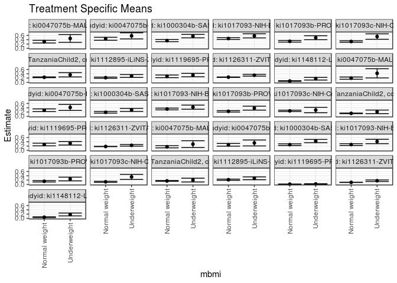

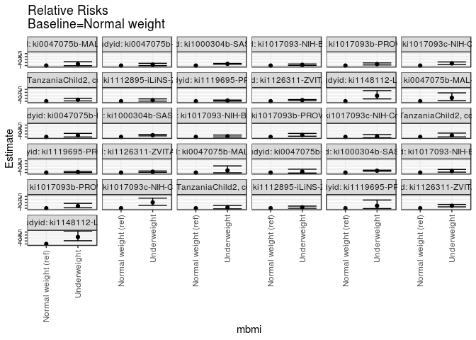

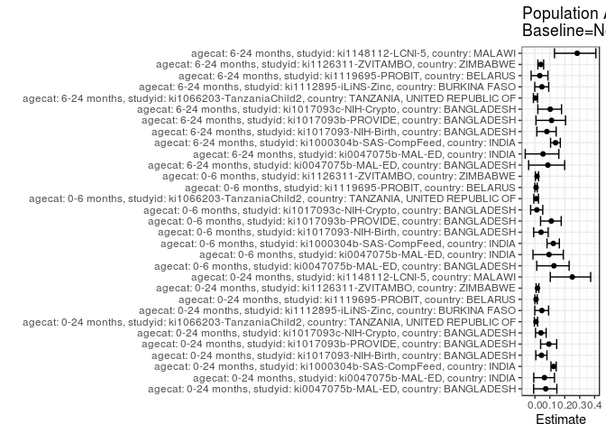

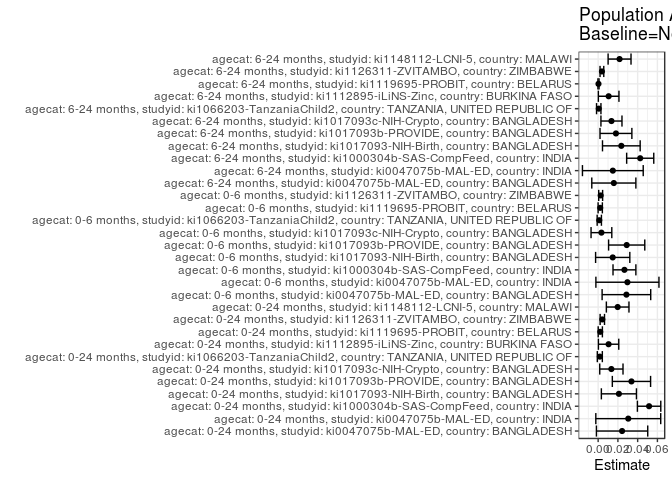

## Results Table

### Parameter: TSM

| agecat | studyid | country | intervention_level | baseline_level | estimate | ci_lower | ci_upper |
| --- | --- | --- | --- | --- | --- | --- | --- |
| 0-24 months | ki0047075b-MAL-ED | BANGLADESH | Normal weight | NA | 0.3104216 | 0.2482912 | 0.3725520 |
| 0-24 months | ki0047075b-MAL-ED | BANGLADESH | Underweight | NA | 0.4612021 | 0.2798263 | 0.6425779 |
| 0-24 months | ki0047075b-MAL-ED | INDIA | Normal weight | NA | 0.4447141 | 0.3742767 | 0.5151514 |
| 0-24 months | ki0047075b-MAL-ED | INDIA | Underweight | NA | 0.5819139 | 0.4393096 | 0.7245182 |
| 0-24 months | ki1000304b-SAS-CompFeed | INDIA | Normal weight | NA | 0.3595104 | 0.3092616 | 0.4097591 |
| 0-24 months | ki1000304b-SAS-CompFeed | INDIA | Underweight | NA | 0.5689667 | 0.4876471 | 0.6502862 |
| 0-24 months | ki1017093-NIH-Birth | BANGLADESH | Normal weight | NA | 0.4565442 | 0.4136654 | 0.4994229 |
| 0-24 months | ki1017093-NIH-Birth | BANGLADESH | Underweight | NA | 0.5801272 | 0.4835743 | 0.6766800 |
| 0-24 months | ki1017093b-PROVIDE | BANGLADESH | Normal weight | NA | 0.3265164 | 0.2866486 | 0.3663843 |
| 0-24 months | ki1017093b-PROVIDE | BANGLADESH | Underweight | NA | 0.4941943 | 0.4011983 | 0.5871902 |
| 0-24 months | ki1017093c-NIH-Crypto | BANGLADESH | Normal weight | NA | 0.3177411 | 0.2827696 | 0.3527125 |
| 0-24 months | ki1017093c-NIH-Crypto | BANGLADESH | Underweight | NA | 0.5490905 | 0.4230388 | 0.6751421 |
| 0-24 months | ki1066203-TanzaniaChild2 | TANZANIA, UNITED REPUBLIC OF | Normal weight | NA | 0.2354115 | 0.2179216 | 0.2529013 |
| 0-24 months | ki1066203-TanzaniaChild2 | TANZANIA, UNITED REPUBLIC OF | Underweight | NA | 0.3517940 | 0.2522604 | 0.4513277 |
| 0-24 months | ki1112895-iLiNS-Zinc | BURKINA FASO | Normal weight | NA | 0.2166266 | 0.1870307 | 0.2462225 |
| 0-24 months | ki1112895-iLiNS-Zinc | BURKINA FASO | Underweight | NA | 0.2962495 | 0.2295452 | 0.3629538 |
| 0-24 months | ki1119695-PROBIT | BELARUS | Normal weight | NA | 0.2795243 | 0.2178255 | 0.3412231 |
| 0-24 months | ki1119695-PROBIT | BELARUS | Underweight | NA | 0.3386353 | 0.2583007 | 0.4189699 |
| 0-24 months | ki1126311-ZVITAMBO | ZIMBABWE | Normal weight | NA | 0.2408569 | 0.2321498 | 0.2495639 |
| 0-24 months | ki1126311-ZVITAMBO | ZIMBABWE | Underweight | NA | 0.3307240 | 0.2885727 | 0.3728752 |
| 0-24 months | ki1148112-LCNI-5 | MALAWI | Normal weight | NA | 0.0590985 | 0.0415730 | 0.0766240 |
| 0-24 months | ki1148112-LCNI-5 | MALAWI | Underweight | NA | 0.1688003 | 0.1070308 | 0.2305698 |
| 0-6 months | ki0047075b-MAL-ED | BANGLADESH | Normal weight | NA | 0.1957935 | 0.1429344 | 0.2486526 |
| 0-6 months | ki0047075b-MAL-ED | BANGLADESH | Underweight | NA | 0.4207624 | 0.2049336 | 0.6365912 |
| 0-6 months | ki0047075b-MAL-ED | INDIA | Normal weight | NA | 0.2844130 | 0.2205231 | 0.3483029 |
| 0-6 months | ki0047075b-MAL-ED | INDIA | Underweight | NA | 0.4157393 | 0.2756917 | 0.5557869 |
| 0-6 months | ki1000304b-SAS-CompFeed | INDIA | Normal weight | NA | 0.1890090 | 0.1494414 | 0.2285766 |
| 0-6 months | ki1000304b-SAS-CompFeed | INDIA | Underweight | NA | 0.2991012 | 0.2274901 | 0.3707123 |
| 0-6 months | ki1017093-NIH-Birth | BANGLADESH | Normal weight | NA | 0.3421734 | 0.3012752 | 0.3830716 |
| 0-6 months | ki1017093-NIH-Birth | BANGLADESH | Underweight | NA | 0.4290616 | 0.3329781 | 0.5251452 |
| 0-6 months | ki1017093b-PROVIDE | BANGLADESH | Normal weight | NA | 0.2341913 | 0.1982984 | 0.2700841 |
| 0-6 months | ki1017093b-PROVIDE | BANGLADESH | Underweight | NA | 0.3826065 | 0.2913855 | 0.4738274 |
| 0-6 months | ki1017093c-NIH-Crypto | BANGLADESH | Normal weight | NA | 0.2549661 | 0.2222661 | 0.2876661 |
| 0-6 months | ki1017093c-NIH-Crypto | BANGLADESH | Underweight | NA | 0.2918127 | 0.1665130 | 0.4171123 |
| 0-6 months | ki1066203-TanzaniaChild2 | TANZANIA, UNITED REPUBLIC OF | Normal weight | NA | 0.1391417 | 0.1248886 | 0.1533949 |
| 0-6 months | ki1066203-TanzaniaChild2 | TANZANIA, UNITED REPUBLIC OF | Underweight | NA | 0.2105263 | 0.1264891 | 0.2945635 |
| 0-6 months | ki1119695-PROBIT | BELARUS | Normal weight | NA | 0.2725863 | 0.2101134 | 0.3350593 |
| 0-6 months | ki1119695-PROBIT | BELARUS | Underweight | NA | 0.3287534 | 0.2477654 | 0.4097414 |
| 0-6 months | ki1126311-ZVITAMBO | ZIMBABWE | Normal weight | NA | 0.1799527 | 0.1721177 | 0.1877876 |
| 0-6 months | ki1126311-ZVITAMBO | ZIMBABWE | Underweight | NA | 0.2341858 | 0.1961454 | 0.2722262 |
| 6-24 months | ki0047075b-MAL-ED | BANGLADESH | Normal weight | NA | 0.1674641 | 0.1167366 | 0.2181917 |
| 6-24 months | ki0047075b-MAL-ED | BANGLADESH | Underweight | NA | 0.2903226 | 0.1302029 | 0.4504423 |
| 6-24 months | ki0047075b-MAL-ED | INDIA | Normal weight | NA | 0.2586350 | 0.1956202 | 0.3216498 |
| 6-24 months | ki0047075b-MAL-ED | INDIA | Underweight | NA | 0.3447125 | 0.2068694 | 0.4825556 |
| 6-24 months | ki1000304b-SAS-CompFeed | INDIA | Normal weight | NA | 0.2654131 | 0.2257227 | 0.3051035 |
| 6-24 months | ki1000304b-SAS-CompFeed | INDIA | Underweight | NA | 0.4339355 | 0.3566321 | 0.5112388 |
| 6-24 months | ki1017093-NIH-Birth | BANGLADESH | Normal weight | NA | 0.2704329 | 0.2292122 | 0.3116535 |
| 6-24 months | ki1017093-NIH-Birth | BANGLADESH | Underweight | NA | 0.4141221 | 0.3123472 | 0.5158970 |
| 6-24 months | ki1017093b-PROVIDE | BANGLADESH | Normal weight | NA | 0.1432256 | 0.1123020 | 0.1741492 |
| 6-24 months | ki1017093b-PROVIDE | BANGLADESH | Underweight | NA | 0.2506701 | 0.1633452 | 0.3379949 |
| 6-24 months | ki1017093c-NIH-Crypto | BANGLADESH | Normal weight | NA | 0.1180389 | 0.0933330 | 0.1427448 |
| 6-24 months | ki1017093c-NIH-Crypto | BANGLADESH | Underweight | NA | 0.3487605 | 0.2299426 | 0.4675784 |
| 6-24 months | ki1066203-TanzaniaChild2 | TANZANIA, UNITED REPUBLIC OF | Normal weight | NA | 0.1606591 | 0.1441588 | 0.1771595 |
| 6-24 months | ki1066203-TanzaniaChild2 | TANZANIA, UNITED REPUBLIC OF | Underweight | NA | 0.2000001 | 0.1128773 | 0.2871230 |
| 6-24 months | ki1112895-iLiNS-Zinc | BURKINA FASO | Normal weight | NA | 0.2165595 | 0.1870187 | 0.2461002 |
| 6-24 months | ki1112895-iLiNS-Zinc | BURKINA FASO | Underweight | NA | 0.2831100 | 0.2176307 | 0.3485894 |
| 6-24 months | ki1119695-PROBIT | BELARUS | Normal weight | NA | 0.0099430 | 0.0067046 | 0.0131814 |
| 6-24 months | ki1119695-PROBIT | BELARUS | Underweight | NA | 0.0182222 | 0.0065204 | 0.0299240 |
| 6-24 months | ki1126311-ZVITAMBO | ZIMBABWE | Normal weight | NA | 0.0927092 | 0.0863897 | 0.0990287 |
| 6-24 months | ki1126311-ZVITAMBO | ZIMBABWE | Underweight | NA | 0.1698913 | 0.1343429 | 0.2054397 |
| 6-24 months | ki1148112-LCNI-5 | MALAWI | Normal weight | NA | 0.0548701 | 0.0378628 | 0.0718774 |
| 6-24 months | ki1148112-LCNI-5 | MALAWI | Underweight | NA | 0.1825163 | 0.1163199 | 0.2487128 |

### Parameter: E(Y)

| agecat | studyid | country | intervention_level | baseline_level | estimate | ci_lower | ci_upper |
| --- | --- | --- | --- | --- | --- | --- | --- |
| 0-24 months | ki0047075b-MAL-ED | BANGLADESH | NA | NA | 0.3346457 | 0.2765014 | 0.3927899 |
| 0-24 months | ki0047075b-MAL-ED | INDIA | NA | NA | 0.4752066 | 0.4121581 | 0.5382551 |
| 0-24 months | ki1000304b-SAS-CompFeed | INDIA | NA | NA | 0.4110871 | 0.3516836 | 0.4704906 |
| 0-24 months | ki1017093-NIH-Birth | BANGLADESH | NA | NA | 0.4775641 | 0.4383415 | 0.5167867 |
| 0-24 months | ki1017093b-PROVIDE | BANGLADESH | NA | NA | 0.3602392 | 0.3238339 | 0.3966444 |
| 0-24 months | ki1017093c-NIH-Crypto | BANGLADESH | NA | NA | 0.3311258 | 0.2975342 | 0.3647175 |
| 0-24 months | ki1066203-TanzaniaChild2 | TANZANIA, UNITED REPUBLIC OF | NA | NA | 0.2371002 | 0.2198828 | 0.2543177 |
| 0-24 months | ki1112895-iLiNS-Zinc | BURKINA FASO | NA | NA | 0.2271869 | 0.2003867 | 0.2539871 |
| 0-24 months | ki1119695-PROBIT | BELARUS | NA | NA | 0.2816871 | 0.2197838 | 0.3435903 |
| 0-24 months | ki1126311-ZVITAMBO | ZIMBABWE | NA | NA | 0.2450750 | 0.2365573 | 0.2535928 |
| 0-24 months | ki1148112-LCNI-5 | MALAWI | NA | NA | 0.0788530 | 0.0605839 | 0.0971222 |
| 0-6 months | ki0047075b-MAL-ED | BANGLADESH | NA | NA | 0.2244094 | 0.1730022 | 0.2758167 |
| 0-6 months | ki0047075b-MAL-ED | INDIA | NA | NA | 0.3140496 | 0.2554513 | 0.3726479 |
| 0-6 months | ki1000304b-SAS-CompFeed | INDIA | NA | NA | 0.2156295 | 0.1693905 | 0.2618686 |
| 0-6 months | ki1017093-NIH-Birth | BANGLADESH | NA | NA | 0.3569132 | 0.3192325 | 0.3945938 |
| 0-6 months | ki1017093b-PROVIDE | BANGLADESH | NA | NA | 0.2630792 | 0.2296894 | 0.2964690 |
| 0-6 months | ki1017093c-NIH-Crypto | BANGLADESH | NA | NA | 0.2582781 | 0.2270370 | 0.2895193 |
| 0-6 months | ki1066203-TanzaniaChild2 | TANZANIA, UNITED REPUBLIC OF | NA | NA | 0.1402985 | 0.1262390 | 0.1543580 |
| 0-6 months | ki1119695-PROBIT | BELARUS | NA | NA | 0.2746941 | 0.2120609 | 0.3373272 |
| 0-6 months | ki1126311-ZVITAMBO | ZIMBABWE | NA | NA | 0.1824982 | 0.1748345 | 0.1901620 |
| 6-24 months | ki0047075b-MAL-ED | BANGLADESH | NA | NA | 0.1833333 | 0.1342773 | 0.2323893 |
| 6-24 months | ki0047075b-MAL-ED | INDIA | NA | NA | 0.2735043 | 0.2162683 | 0.3307402 |
| 6-24 months | ki1000304b-SAS-CompFeed | INDIA | NA | NA | 0.3079937 | 0.2595409 | 0.3564465 |
| 6-24 months | ki1017093-NIH-Birth | BANGLADESH | NA | NA | 0.2939002 | 0.2554778 | 0.3323226 |
| 6-24 months | ki1017093b-PROVIDE | BANGLADESH | NA | NA | 0.1612378 | 0.1321259 | 0.1903497 |
| 6-24 months | ki1017093c-NIH-Crypto | BANGLADESH | NA | NA | 0.1315068 | 0.1069744 | 0.1560393 |
| 6-24 months | ki1066203-TanzaniaChild2 | TANZANIA, UNITED REPUBLIC OF | NA | NA | 0.1612576 | 0.1450216 | 0.1774936 |
| 6-24 months | ki1112895-iLiNS-Zinc | BURKINA FASO | NA | NA | 0.2271869 | 0.2003867 | 0.2539871 |
| 6-24 months | ki1119695-PROBIT | BELARUS | NA | NA | 0.0102770 | 0.0071241 | 0.0134298 |
| 6-24 months | ki1126311-ZVITAMBO | ZIMBABWE | NA | NA | 0.0965066 | 0.0902505 | 0.1027627 |
| 6-24 months | ki1148112-LCNI-5 | MALAWI | NA | NA | 0.0765492 | 0.0583736 | 0.0947248 |

### Parameter: RR

| agecat | studyid | country | intervention_level | baseline_level | estimate | ci_lower | ci_upper |
| --- | --- | --- | --- | --- | --- | --- | --- |
| 0-24 months | ki0047075b-MAL-ED | BANGLADESH | Normal weight | Normal weight | 1.000000 | 1.0000000 | 1.000000 |
| 0-24 months | ki0047075b-MAL-ED | BANGLADESH | Underweight | Normal weight | 1.485728 | 0.9562283 | 2.308432 |
| 0-24 months | ki0047075b-MAL-ED | INDIA | Normal weight | Normal weight | 1.000000 | 1.0000000 | 1.000000 |
| 0-24 months | ki0047075b-MAL-ED | INDIA | Underweight | Normal weight | 1.308512 | 0.9761993 | 1.753950 |
| 0-24 months | ki1000304b-SAS-CompFeed | INDIA | Normal weight | Normal weight | 1.000000 | 1.0000000 | 1.000000 |
| 0-24 months | ki1000304b-SAS-CompFeed | INDIA | Underweight | Normal weight | 1.582615 | 1.4625822 | 1.712500 |
| 0-24 months | ki1017093-NIH-Birth | BANGLADESH | Normal weight | Normal weight | 1.000000 | 1.0000000 | 1.000000 |
| 0-24 months | ki1017093-NIH-Birth | BANGLADESH | Underweight | Normal weight | 1.270692 | 1.0496552 | 1.538276 |
| 0-24 months | ki1017093b-PROVIDE | BANGLADESH | Normal weight | Normal weight | 1.000000 | 1.0000000 | 1.000000 |
| 0-24 months | ki1017093b-PROVIDE | BANGLADESH | Underweight | Normal weight | 1.513536 | 1.2092477 | 1.894393 |
| 0-24 months | ki1017093c-NIH-Crypto | BANGLADESH | Normal weight | Normal weight | 1.000000 | 1.0000000 | 1.000000 |
| 0-24 months | ki1017093c-NIH-Crypto | BANGLADESH | Underweight | Normal weight | 1.728107 | 1.3393135 | 2.229764 |
| 0-24 months | ki1066203-TanzaniaChild2 | TANZANIA, UNITED REPUBLIC OF | Normal weight | Normal weight | 1.000000 | 1.0000000 | 1.000000 |
| 0-24 months | ki1066203-TanzaniaChild2 | TANZANIA, UNITED REPUBLIC OF | Underweight | Normal weight | 1.494379 | 1.1153182 | 2.002271 |
| 0-24 months | ki1112895-iLiNS-Zinc | BURKINA FASO | Normal weight | Normal weight | 1.000000 | 1.0000000 | 1.000000 |
| 0-24 months | ki1112895-iLiNS-Zinc | BURKINA FASO | Underweight | Normal weight | 1.367558 | 1.0443886 | 1.790728 |
| 0-24 months | ki1119695-PROBIT | BELARUS | Normal weight | Normal weight | 1.000000 | 1.0000000 | 1.000000 |
| 0-24 months | ki1119695-PROBIT | BELARUS | Underweight | Normal weight | 1.211470 | 1.0450901 | 1.404338 |
| 0-24 months | ki1126311-ZVITAMBO | ZIMBABWE | Normal weight | Normal weight | 1.000000 | 1.0000000 | 1.000000 |
| 0-24 months | ki1126311-ZVITAMBO | ZIMBABWE | Underweight | Normal weight | 1.373114 | 1.2027008 | 1.567674 |
| 0-24 months | ki1148112-LCNI-5 | MALAWI | Normal weight | Normal weight | 1.000000 | 1.0000000 | 1.000000 |
| 0-24 months | ki1148112-LCNI-5 | MALAWI | Underweight | Normal weight | 2.856253 | 1.7821384 | 4.577750 |
| 0-6 months | ki0047075b-MAL-ED | BANGLADESH | Normal weight | Normal weight | 1.000000 | 1.0000000 | 1.000000 |
| 0-6 months | ki0047075b-MAL-ED | BANGLADESH | Underweight | Normal weight | 2.149011 | 1.2075580 | 3.824451 |
| 0-6 months | ki0047075b-MAL-ED | INDIA | Normal weight | Normal weight | 1.000000 | 1.0000000 | 1.000000 |
| 0-6 months | ki0047075b-MAL-ED | INDIA | Underweight | Normal weight | 1.461745 | 0.9744372 | 2.192751 |
| 0-6 months | ki1000304b-SAS-CompFeed | INDIA | Normal weight | Normal weight | 1.000000 | 1.0000000 | 1.000000 |
| 0-6 months | ki1000304b-SAS-CompFeed | INDIA | Underweight | Normal weight | 1.582471 | 1.3487149 | 1.856741 |
| 0-6 months | ki1017093-NIH-Birth | BANGLADESH | Normal weight | Normal weight | 1.000000 | 1.0000000 | 1.000000 |
| 0-6 months | ki1017093-NIH-Birth | BANGLADESH | Underweight | Normal weight | 1.253930 | 0.9732152 | 1.615615 |
| 0-6 months | ki1017093b-PROVIDE | BANGLADESH | Normal weight | Normal weight | 1.000000 | 1.0000000 | 1.000000 |
| 0-6 months | ki1017093b-PROVIDE | BANGLADESH | Underweight | Normal weight | 1.633735 | 1.2298820 | 2.170200 |
| 0-6 months | ki1017093c-NIH-Crypto | BANGLADESH | Normal weight | Normal weight | 1.000000 | 1.0000000 | 1.000000 |
| 0-6 months | ki1017093c-NIH-Crypto | BANGLADESH | Underweight | Normal weight | 1.144516 | 0.7307447 | 1.792577 |
| 0-6 months | ki1066203-TanzaniaChild2 | TANZANIA, UNITED REPUBLIC OF | Normal weight | Normal weight | 1.000000 | 1.0000000 | 1.000000 |
| 0-6 months | ki1066203-TanzaniaChild2 | TANZANIA, UNITED REPUBLIC OF | Underweight | Normal weight | 1.513035 | 1.0020087 | 2.284685 |
| 0-6 months | ki1119695-PROBIT | BELARUS | Normal weight | Normal weight | 1.000000 | 1.0000000 | 1.000000 |
| 0-6 months | ki1119695-PROBIT | BELARUS | Underweight | Normal weight | 1.206052 | 1.0305279 | 1.411473 |
| 0-6 months | ki1126311-ZVITAMBO | ZIMBABWE | Normal weight | Normal weight | 1.000000 | 1.0000000 | 1.000000 |
| 0-6 months | ki1126311-ZVITAMBO | ZIMBABWE | Underweight | Normal weight | 1.301374 | 1.0999041 | 1.539748 |
| 6-24 months | ki0047075b-MAL-ED | BANGLADESH | Normal weight | Normal weight | 1.000000 | 1.0000000 | 1.000000 |
| 6-24 months | ki0047075b-MAL-ED | BANGLADESH | Underweight | Normal weight | 1.733641 | 0.9240297 | 3.252611 |
| 6-24 months | ki0047075b-MAL-ED | INDIA | Normal weight | Normal weight | 1.000000 | 1.0000000 | 1.000000 |
| 6-24 months | ki0047075b-MAL-ED | INDIA | Underweight | Normal weight | 1.332814 | 0.8340886 | 2.129743 |
| 6-24 months | ki1000304b-SAS-CompFeed | INDIA | Normal weight | Normal weight | 1.000000 | 1.0000000 | 1.000000 |
| 6-24 months | ki1000304b-SAS-CompFeed | INDIA | Underweight | Normal weight | 1.634944 | 1.4729736 | 1.814724 |
| 6-24 months | ki1017093-NIH-Birth | BANGLADESH | Normal weight | Normal weight | 1.000000 | 1.0000000 | 1.000000 |
| 6-24 months | ki1017093-NIH-Birth | BANGLADESH | Underweight | Normal weight | 1.531330 | 1.1458259 | 2.046535 |
| 6-24 months | ki1017093b-PROVIDE | BANGLADESH | Normal weight | Normal weight | 1.000000 | 1.0000000 | 1.000000 |
| 6-24 months | ki1017093b-PROVIDE | BANGLADESH | Underweight | Normal weight | 1.750177 | 1.1610694 | 2.638187 |
| 6-24 months | ki1017093c-NIH-Crypto | BANGLADESH | Normal weight | Normal weight | 1.000000 | 1.0000000 | 1.000000 |
| 6-24 months | ki1017093c-NIH-Crypto | BANGLADESH | Underweight | Normal weight | 2.954624 | 1.9800988 | 4.408771 |
| 6-24 months | ki1066203-TanzaniaChild2 | TANZANIA, UNITED REPUBLIC OF | Normal weight | Normal weight | 1.000000 | 1.0000000 | 1.000000 |
| 6-24 months | ki1066203-TanzaniaChild2 | TANZANIA, UNITED REPUBLIC OF | Underweight | Normal weight | 1.244873 | 0.7957071 | 1.947586 |
| 6-24 months | ki1112895-iLiNS-Zinc | BURKINA FASO | Normal weight | Normal weight | 1.000000 | 1.0000000 | 1.000000 |
| 6-24 months | ki1112895-iLiNS-Zinc | BURKINA FASO | Underweight | Normal weight | 1.307309 | 0.9894762 | 1.727233 |
| 6-24 months | ki1119695-PROBIT | BELARUS | Normal weight | Normal weight | 1.000000 | 1.0000000 | 1.000000 |
| 6-24 months | ki1119695-PROBIT | BELARUS | Underweight | Normal weight | 1.832658 | 0.8889313 | 3.778283 |
| 6-24 months | ki1126311-ZVITAMBO | ZIMBABWE | Normal weight | Normal weight | 1.000000 | 1.0000000 | 1.000000 |
| 6-24 months | ki1126311-ZVITAMBO | ZIMBABWE | Underweight | Normal weight | 1.832518 | 1.4705052 | 2.283653 |
| 6-24 months | ki1148112-LCNI-5 | MALAWI | Normal weight | Normal weight | 1.000000 | 1.0000000 | 1.000000 |
| 6-24 months | ki1148112-LCNI-5 | MALAWI | Underweight | Normal weight | 3.326336 | 2.0630205 | 5.363258 |

### Parameter: PAR

| agecat | studyid | country | intervention_level | baseline_level | estimate | ci_lower | ci_upper |
| --- | --- | --- | --- | --- | --- | --- | --- |
| 0-24 months | ki0047075b-MAL-ED | BANGLADESH | Normal weight | NA | 0.0242241 | -0.0017576 | 0.0502058 |
| 0-24 months | ki0047075b-MAL-ED | INDIA | Normal weight | NA | 0.0304925 | -0.0023675 | 0.0633526 |
| 0-24 months | ki1000304b-SAS-CompFeed | INDIA | Normal weight | NA | 0.0515767 | 0.0397394 | 0.0634141 |
| 0-24 months | ki1017093-NIH-Birth | BANGLADESH | Normal weight | NA | 0.0210199 | 0.0032526 | 0.0387873 |
| 0-24 months | ki1017093b-PROVIDE | BANGLADESH | Normal weight | NA | 0.0337227 | 0.0143497 | 0.0530957 |
| 0-24 months | ki1017093c-NIH-Crypto | BANGLADESH | Normal weight | NA | 0.0133848 | 0.0016024 | 0.0251672 |
| 0-24 months | ki1066203-TanzaniaChild2 | TANZANIA, UNITED REPUBLIC OF | Normal weight | NA | 0.0016887 | -0.0008515 | 0.0042290 |
| 0-24 months | ki1112895-iLiNS-Zinc | BURKINA FASO | Normal weight | NA | 0.0105603 | 0.0002532 | 0.0208674 |
| 0-24 months | ki1119695-PROBIT | BELARUS | Normal weight | NA | 0.0021628 | 0.0000390 | 0.0042866 |
| 0-24 months | ki1126311-ZVITAMBO | ZIMBABWE | Normal weight | NA | 0.0042182 | 0.0019958 | 0.0064406 |
| 0-24 months | ki1148112-LCNI-5 | MALAWI | Normal weight | NA | 0.0197546 | 0.0083059 | 0.0312032 |
| 0-6 months | ki0047075b-MAL-ED | BANGLADESH | Normal weight | NA | 0.0286159 | 0.0040103 | 0.0532216 |
| 0-6 months | ki0047075b-MAL-ED | INDIA | Normal weight | NA | 0.0296366 | -0.0022931 | 0.0615663 |
| 0-6 months | ki1000304b-SAS-CompFeed | INDIA | Normal weight | NA | 0.0266206 | 0.0150476 | 0.0381935 |
| 0-6 months | ki1017093-NIH-Birth | BANGLADESH | Normal weight | NA | 0.0147398 | -0.0025814 | 0.0320609 |
| 0-6 months | ki1017093b-PROVIDE | BANGLADESH | Normal weight | NA | 0.0288880 | 0.0105691 | 0.0472068 |
| 0-6 months | ki1017093c-NIH-Crypto | BANGLADESH | Normal weight | NA | 0.0033121 | -0.0071875 | 0.0138116 |
| 0-6 months | ki1066203-TanzaniaChild2 | TANZANIA, UNITED REPUBLIC OF | Normal weight | NA | 0.0011568 | -0.0010052 | 0.0033187 |
| 0-6 months | ki1119695-PROBIT | BELARUS | Normal weight | NA | 0.0021077 | -0.0000493 | 0.0042648 |
| 0-6 months | ki1126311-ZVITAMBO | ZIMBABWE | Normal weight | NA | 0.0025455 | 0.0005690 | 0.0045221 |
| 6-24 months | ki0047075b-MAL-ED | BANGLADESH | Normal weight | NA | 0.0158692 | -0.0064461 | 0.0381845 |
| 6-24 months | ki0047075b-MAL-ED | INDIA | Normal weight | NA | 0.0148693 | -0.0158998 | 0.0456383 |
| 6-24 months | ki1000304b-SAS-CompFeed | INDIA | Normal weight | NA | 0.0425806 | 0.0288580 | 0.0563032 |
| 6-24 months | ki1017093-NIH-Birth | BANGLADESH | Normal weight | NA | 0.0234673 | 0.0043970 | 0.0425376 |
| 6-24 months | ki1017093b-PROVIDE | BANGLADESH | Normal weight | NA | 0.0180122 | 0.0018833 | 0.0341411 |
| 6-24 months | ki1017093c-NIH-Crypto | BANGLADESH | Normal weight | NA | 0.0134679 | 0.0028122 | 0.0241237 |
| 6-24 months | ki1066203-TanzaniaChild2 | TANZANIA, UNITED REPUBLIC OF | Normal weight | NA | 0.0005985 | -0.0016285 | 0.0028255 |
| 6-24 months | ki1112895-iLiNS-Zinc | BURKINA FASO | Normal weight | NA | 0.0106274 | 0.0001969 | 0.0210579 |
| 6-24 months | ki1119695-PROBIT | BELARUS | Normal weight | NA | 0.0003339 | -0.0002289 | 0.0008968 |
| 6-24 months | ki1126311-ZVITAMBO | ZIMBABWE | Normal weight | NA | 0.0037974 | 0.0019178 | 0.0056770 |
| 6-24 months | ki1148112-LCNI-5 | MALAWI | Normal weight | NA | 0.0216791 | 0.0100803 | 0.0332780 |

### Parameter: PAF

| agecat | studyid | country | intervention_level | baseline_level | estimate | ci_lower | ci_upper |
| --- | --- | --- | --- | --- | --- | --- | --- |
| 0-24 months | ki0047075b-MAL-ED | BANGLADESH | Normal weight | NA | 0.0723872 | -0.0088159 | 0.1470540 |
| 0-24 months | ki0047075b-MAL-ED | INDIA | Normal weight | NA | 0.0641669 | -0.0079575 | 0.1311304 |
| 0-24 months | ki1000304b-SAS-CompFeed | INDIA | Normal weight | NA | 0.1254642 | 0.1077208 | 0.1428548 |
| 0-24 months | ki1017093-NIH-Birth | BANGLADESH | Normal weight | NA | 0.0440149 | 0.0059368 | 0.0806344 |
| 0-24 months | ki1017093b-PROVIDE | BANGLADESH | Normal weight | NA | 0.0936121 | 0.0381151 | 0.1459071 |
| 0-24 months | ki1017093c-NIH-Crypto | BANGLADESH | Normal weight | NA | 0.0404220 | 0.0041637 | 0.0753601 |
| 0-24 months | ki1066203-TanzaniaChild2 | TANZANIA, UNITED REPUBLIC OF | Normal weight | NA | 0.0071224 | -0.0036799 | 0.0178086 |
| 0-24 months | ki1112895-iLiNS-Zinc | BURKINA FASO | Normal weight | NA | 0.0464830 | -0.0008571 | 0.0915839 |
| 0-24 months | ki1119695-PROBIT | BELARUS | Normal weight | NA | 0.0076780 | 0.0001121 | 0.0151867 |
| 0-24 months | ki1126311-ZVITAMBO | ZIMBABWE | Normal weight | NA | 0.0172117 | 0.0081084 | 0.0262315 |
| 0-24 months | ki1148112-LCNI-5 | MALAWI | Normal weight | NA | 0.2505237 | 0.1031771 | 0.3736615 |
| 0-6 months | ki0047075b-MAL-ED | BANGLADESH | Normal weight | NA | 0.1275166 | 0.0122239 | 0.2293524 |
| 0-6 months | ki0047075b-MAL-ED | INDIA | Normal weight | NA | 0.0943691 | -0.0129791 | 0.1903414 |
| 0-6 months | ki1000304b-SAS-CompFeed | INDIA | Normal weight | NA | 0.1234551 | 0.0811654 | 0.1637983 |
| 0-6 months | ki1017093-NIH-Birth | BANGLADESH | Normal weight | NA | 0.0412979 | -0.0085221 | 0.0886569 |
| 0-6 months | ki1017093b-PROVIDE | BANGLADESH | Normal weight | NA | 0.1098071 | 0.0378698 | 0.1763657 |
| 0-6 months | ki1017093c-NIH-Crypto | BANGLADESH | Normal weight | NA | 0.0128236 | -0.0286663 | 0.0526401 |
| 0-6 months | ki1066203-TanzaniaChild2 | TANZANIA, UNITED REPUBLIC OF | Normal weight | NA | 0.0082450 | -0.0073186 | 0.0235682 |
| 0-6 months | ki1119695-PROBIT | BELARUS | Normal weight | NA | 0.0076730 | -0.0002459 | 0.0155292 |
| 0-6 months | ki1126311-ZVITAMBO | ZIMBABWE | Normal weight | NA | 0.0139483 | 0.0030666 | 0.0247113 |
| 6-24 months | ki0047075b-MAL-ED | BANGLADESH | Normal weight | NA | 0.0865594 | -0.0421507 | 0.1993732 |
| 6-24 months | ki0047075b-MAL-ED | INDIA | Normal weight | NA | 0.0543658 | -0.0648305 | 0.1602193 |
| 6-24 months | ki1000304b-SAS-CompFeed | INDIA | Normal weight | NA | 0.1382516 | 0.1051017 | 0.1701735 |
| 6-24 months | ki1017093-NIH-Birth | BANGLADESH | Normal weight | NA | 0.0798479 | 0.0127938 | 0.1423476 |
| 6-24 months | ki1017093b-PROVIDE | BANGLADESH | Normal weight | NA | 0.1117120 | 0.0072010 | 0.2052212 |
| 6-24 months | ki1017093c-NIH-Crypto | BANGLADESH | Normal weight | NA | 0.1024125 | 0.0193645 | 0.1784274 |
| 6-24 months | ki1066203-TanzaniaChild2 | TANZANIA, UNITED REPUBLIC OF | Normal weight | NA | 0.0037114 | -0.0102191 | 0.0174499 |
| 6-24 months | ki1112895-iLiNS-Zinc | BURKINA FASO | Normal weight | NA | 0.0467784 | -0.0010706 | 0.0923404 |
| 6-24 months | ki1119695-PROBIT | BELARUS | Normal weight | NA | 0.0324946 | -0.0254767 | 0.0871887 |
| 6-24 months | ki1126311-ZVITAMBO | ZIMBABWE | Normal weight | NA | 0.0393486 | 0.0198061 | 0.0585015 |
| 6-24 months | ki1148112-LCNI-5 | MALAWI | Normal weight | NA | 0.2832052 | 0.1312552 | 0.4085780 |